# EDA play store project

```python
import numpy as np
import pandas as pd
import matplotlib.pyplot as plt
import seaborn as sns
```

```python
play_store = pd.read_csv(r"D:\Grras\Grras\Play Store Data.csv")
```

```python
df=play_store.copy()
```

```python
df
```

|  | App | Category | Rating | Reviews | Size | Installs | Type | Price | Content Rating | Genres | Last Updated | Current Ver | Android Ver |
| --- | --- | --- | --- | --- | --- | --- | --- | --- | --- | --- | --- | --- | --- |
| 0 | Photo Editor & Candy Camera & Grid & ScrapBook | ART_AND_DESIGN | 4.1 | 159 | 19M | 10,000+ | Free | 0 | Everyone | Art & Design | January 7, 2018 | 1.0.0 | 4.0.3 and up |
| 1 | Coloring book moana | ART_AND_DESIGN | 3.9 | 967 | 14M | 500,000+ | Free | 0 | Everyone | Art & Design;Pretend Play | January 15, 2018 | 2.0.0 | 4.0.3 and up |
| 2 | U Launcher Lite – FREE Live Cool Themes, Hide ... | ART_AND_DESIGN | 4.7 | 87510 | 8.7M | 5,000,000+ | Free | 0 | Everyone | Art & Design | August 1, 2018 | 1.2.4 | 4.0.3 and up |
| 3 | Sketch - Draw & Paint | ART_AND_DESIGN | 4.5 | 215644 | 25M | 50,000,000+ | Free | 0 | Teen | Art & Design | June 8, 2018 | Varies with device | 4.2 and up |
| 4 | Pixel Draw - Number Art Coloring Book | ART_AND_DESIGN | 4.3 | 967 | 2.8M | 100,000+ | Free | 0 | Everyone | Art & Design;Creativity | June 20, 2018 | 1.1 | 4.4 and up |
| ... | ... | ... | ... | ... | ... | ... | ... | ... | ... | ... | ... | ... | ... |
| 10836 | Sya9a Maroc - FR | FAMILY | 4.5 | 38 | 53M | 5,000+ | Free | 0 | Everyone | Education | July 25, 2017 | 1.48 | 4.1 and up |
| 10837 | Fr. Mike Schmitz Audio Teachings | FAMILY | 5.0 | 4 | 3.6M | 100+ | Free | 0 | Everyone | Education | July 6, 2018 | 1.0 | 4.1 and up |
| 10838 | Parkinson Exercices FR | MEDICAL | NaN | 3 | 9.5M | 1,000+ | Free | 0 | Everyone | Medical | January 20, 2017 | 1.0 | 2.2 and up |
| 10839 | The SCP Foundation DB fr nn5n | BOOKS_AND_REFERENCE | 4.5 | 114 | Varies with device | 1,000+ | Free | 0 | Mature 17+ | Books & Reference | January 19, 2015 | Varies with device | Varies with device |
| 10840 | iHoroscope - 2018 Daily Horoscope & Astrology | LIFESTYLE | 4.5 | 398307 | 19M | 10,000,000+ | Free | 0 | Everyone | Lifestyle | July 25, 2018 | Varies with device | Varies with device |

10841 rows × 13 columns

```python
df.head()
```

|  | App | Category | Rating | Reviews | Size | Installs | Type | Price | Content Rating | Genres | Last Updated | Current Ver | Android Ver |
| --- | --- | --- | --- | --- | --- | --- | --- | --- | --- | --- | --- | --- | --- |
| 0 | Photo Editor & Candy Camera & Grid & ScrapBook | ART_AND_DESIGN | 4.1 | 159 | 19M | 10,000+ | Free | 0 | Everyone | Art & Design | January 7, 2018 | 1.0.0 | 4.0.3 and up |
| 1 | Coloring book moana | ART_AND_DESIGN | 3.9 | 967 | 14M | 500,000+ | Free | 0 | Everyone | Art & Design;Pretend Play | January 15, 2018 | 2.0.0 | 4.0.3 and up |
| 2 | U Launcher Lite – FREE Live Cool Themes, Hide ... | ART_AND_DESIGN | 4.7 | 87510 | 8.7M | 5,000,000+ | Free | 0 | Everyone | Art & Design | August 1, 2018 | 1.2.4 | 4.0.3 and up |
| 3 | Sketch - Draw & Paint | ART_AND_DESIGN | 4.5 | 215644 | 25M | 50,000,000+ | Free | 0 | Teen | Art & Design | June 8, 2018 | Varies with device | 4.2 and up |
| 4 | Pixel Draw - Number Art Coloring Book | ART_AND_DESIGN | 4.3 | 967 | 2.8M | 100,000+ | Free | 0 | Everyone | Art & Design;Creativity | June 20, 2018 | 1.1 | 4.4 and up |

diffeneriate betweeen the numrical columns and the categorical column in the data et

Overview of the dataset

```python
rows = df.shape[0]
columns = df.shape[1]
print(f"the number of rows  are : {rows}\nand the number of  columns are :{columns}")
```

```
the number of rows  are : 10841
and the number of  columns are :13
```

```python
df.describe()
```

|  | Rating |
| --- | --- |
| count | 9367.000000 |
| mean | 4.193338 |
| std | 0.537431 |
| min | 1.000000 |
| 25% | 4.000000 |
| 50% | 4.300000 |
| 75% | 4.500000 |
| max | 19.000000 |

Univriate analysis on the app column

> App column specifies tha the app which are present in the play store and and they are been download with short description

1.There are 9660 unique apps in the dataset mns

2.89.11% apps are unique in the dataset

3.10.89% apps are repeated in the dataset

4.There are 0 null values in the app columns

```python
df['App'].unique()
```

```
array(['Photo Editor & Candy Camera & Grid & ScrapBook',
       'Coloring book moana',
       'U Launcher Lite – FREE Live Cool Themes, Hide Apps', ...,
       'Parkinson Exercices FR', 'The SCP Foundation DB fr nn5n',
       'iHoroscope - 2018 Daily Horoscope & Astrology'], dtype=object)
```

```python
apps = df['App'].nunique()
print(f"unique apps  in the dataset :{apps}")
```

```
unique apps  in the dataset :9660
```

```python
df['App'].isnull().sum()
```

```
0
```

Univriate analysis on the Category column

1,There are total 34 category in the dataset. ROR

2.0.31% of category is unique in the dataset

4.ERROR

> THERE IS ONE ERROR IN THE CATEGORY COLUMN

A. In the last there one category which is in string format named 1.9 and rest are in the words

```python
df['Category'].isnull().sum()
```

```
0
```

```python
df['Category'].value_counts().head(3)
```

```
Category
FAMILY    1972
GAME      1144
TOOLS      843
Name: count, dtype: int64
```

```python
df['Category'].value_counts().head(3)
```

```
Category
FAMILY    1972
GAME      1144
TOOLS      843
Name: count, dtype: int64
```

```python
df['Category'].unique()
```

```
array(['ART_AND_DESIGN', 'AUTO_AND_VEHICLES', 'BEAUTY',
       'BOOKS_AND_REFERENCE', 'BUSINESS', 'COMICS', 'COMMUNICATION',
       'DATING', 'EDUCATION', 'ENTERTAINMENT', 'EVENTS', 'FINANCE',
       'FOOD_AND_DRINK', 'HEALTH_AND_FITNESS', 'HOUSE_AND_HOME',
       'LIBRARIES_AND_DEMO', 'LIFESTYLE', 'GAME', 'FAMILY', 'MEDICAL',
       'SOCIAL', 'SHOPPING', 'PHOTOGRAPHY', 'SPORTS', 'TRAVEL_AND_LOCAL',
       'TOOLS', 'PERSONALIZATION', 'PRODUCTIVITY', 'PARENTING', 'WEATHER',
       'VIDEO_PLAYERS', 'NEWS_AND_MAGAZINES', 'MAPS_AND_NAVIGATION',
       '1.9'], dtype=object)
```

```python
len(df['Category'])
```

```
10841
```

```python
pecentage_of_uniquenes = round(category_numbers/len(df['Category'])*100,2)
print(f"{pecentage_of_uniquenes}% this is percentage of apps which are unique in the dataset")
```

```
0.31% this is percentage of apps which are unique in the dataset
```

UNIVARIATE ANALYSIS ON THE RATING COLUMN

-Rating column specifies the rating of each app placed in the play store

2.Around 13.6 % are null values present in the dataset.

3.The highest rating is 4.4 in the dataset which are 1109 counts .

4.Total there are 33 category which got 4.4 Ratings

5.Total there are 897 Apps which got 4.4 Ratings

7.Only 9.29% Apps got the 4.4 Ratings which is highest

8.4.19 is the mean for rating column excluding the null values

9.4.3 is the median for rating column excluding the null values

> ERROR

> There is one error in the Ratings columns that all the ratings are under 5 but one rating in (19) mention in the box plot

```python
df['Rating'].value_counts().sort_index(ascending = False)
```

```
Rating
19.0       1
5.0      274
4.9       87
4.8      234
4.7      499
4.6      823
4.5     1038
4.4     1109
4.3     1076
4.2      952
4.1      708
4.0      568
3.9      386
3.8      303
3.7      239
3.6      174
3.5      163
3.4      128
3.3      102
3.2       64
3.1       69
3.0       83
2.9       45
2.8       42
2.7       25
2.6       25
2.5       21
2.4       19
2.3       20
2.2       14
2.1        8
2.0       12
1.9       13
1.8        8
1.7        8
1.6        4
1.5        3
1.4        3
1.2        1
1.0       16
Name: count, dtype: int64
```

```python
null_ratings = df['Rating'].isnull().sum()
null_ratings
```

```
1474
```

```python
null_percentage = round(null_ratings/len(df['Rating'])*100,2)
print(f"There are total {null_percentage}% null values in the ratings columns")
```

```
There are total 13.6% null values in the ratings columns
```

```python
df[df['Rating'] == 4.4]['Category'].unique()
```

```
array(['ART_AND_DESIGN', 'AUTO_AND_VEHICLES', 'BEAUTY',
       'BOOKS_AND_REFERENCE', 'BUSINESS', 'COMICS', 'COMMUNICATION',
       'DATING', 'EDUCATION', 'ENTERTAINMENT', 'EVENTS', 'FINANCE',
       'FOOD_AND_DRINK', 'HEALTH_AND_FITNESS', 'HOUSE_AND_HOME',
       'LIBRARIES_AND_DEMO', 'LIFESTYLE', 'GAME', 'FAMILY', 'MEDICAL',
       'SOCIAL', 'SHOPPING', 'PHOTOGRAPHY', 'SPORTS', 'TRAVEL_AND_LOCAL',
       'TOOLS', 'PERSONALIZATION', 'PRODUCTIVITY', 'PARENTING', 'WEATHER',
       'VIDEO_PLAYERS', 'NEWS_AND_MAGAZINES', 'MAPS_AND_NAVIGATION'],
      dtype=object)
```

```python
df[df['Rating'] == 4.4]['Category'].nunique()
```

```
33
```

```python
df[df['Rating']== 4.4]['App'].nunique()
```

```
897
```

```python
df[df['Rating'] == 19]
```

|  | App | Category | Rating | Reviews | Size | Installs | Type | Price | Content Rating | Genres | Last Updated | Current Ver | Android Ver |
| --- | --- | --- | --- | --- | --- | --- | --- | --- | --- | --- | --- | --- | --- |
| 10472 | Life Made WI-Fi Touchscreen Photo Frame | 1.9 | 19.0 | 3.0M | 1,000+ | Free | 0 | Everyone | NaN | February 11, 2018 | 1.0.19 | 4.0 and up | NaN |

```python
total_Category = df[df['Rating'] == 4.4]['Category'].nunique()
total_Category
```

```
33
```

```python
percentage_of_highest_ratings_in_categories = round(total_Category/len(df['Rating'].unique())*100,2)
print(f"Only {percentage_of_highest_ratings_in_categories}% of categories have got 4.4 ratings")
```

```
Only 80.49% of categories have got 4.4 ratings
```

```python
percentage_of_highest_ratings_in_Apps = df[df['Rating'] == 4.4]['App'].nunique()
percentage_of_highest_ratings_in_Apps
```

```
897
```

```python
len(df['App'].unique())
```

```
9660
```

```python
highest_rating_app = round(percentage_of_highest_ratings_in_Apps/len(df['App'].unique())*100,2)
print(f"total {highest_rating_app}% Apps got the 4.4 Ratings which  is highest")
```

```
total 9.29% Apps got the 4.4 Ratings which  is highest
```

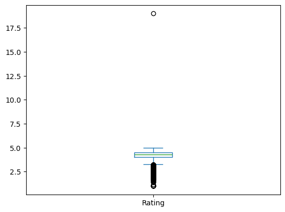

```python
df['Rating'].plot(kind = 'box')
```

```python
round(df[df['Rating'].notnull()]['Rating'].mean(),2)
df[df['Rating'].notnull()]['Rating'].median()
```

```
4.3
```

```python
df[df['Reviews'] == df['Reviews'].max()]
```

|  | App | Category | Rating | Reviews | Size | Installs | Type | Price | Content Rating | Genres | Last Updated | Current Ver | Android Ver |
| --- | --- | --- | --- | --- | --- | --- | --- | --- | --- | --- | --- | --- | --- |
| 2989 | GollerCepte Live Score | SPORTS | 4.2 | 9992 | 31M | 1,000,000+ | Free | 0 | Everyone | Sports | May 23, 2018 | 6.5 | 4.1 and up |

```python
df[df['Reviews'] == df['Reviews'].min()]
```

|  | App | Category | Rating | Reviews | Size | Installs | Type | Price | Content Rating | Genres | Last Updated | Current Ver | Android Ver |
| --- | --- | --- | --- | --- | --- | --- | --- | --- | --- | --- | --- | --- | --- |
| 478 | Truth or Dare Pro | DATING | NaN | 0 | 20M | 50+ | Paid | $1.49 | Teen | Dating | September 1, 2017 | 1.0 | 4.0 and up |
| 479 | Private Dating, Hide App- Blue for PrivacyHider | DATING | NaN | 0 | 18k | 100+ | Paid | $2.99 | Everyone | Dating | July 25, 2017 | 1.0.1 | 4.0 and up |
| 621 | Dating White Girls | DATING | NaN | 0 | 3.6M | 50+ | Free | 0 | Mature 17+ | Dating | July 20, 2018 | 1.0 | 4.0 and up |
| 623 | Geeks Dating | DATING | NaN | 0 | 13M | 50+ | Free | 0 | Mature 17+ | Dating | July 10, 2018 | 1.0 | 4.1 and up |
| 627 | CAM5678 Video Chat | DATING | NaN | 0 | 39M | 500+ | Free | 0 | Mature 17+ | Dating | July 13, 2018 | 5.5.8 | 4.0.3 and up |
| ... | ... | ... | ... | ... | ... | ... | ... | ... | ... | ... | ... | ... | ... |
| 10773 | FQ India | LIFESTYLE | NaN | 0 | 8.9M | 10+ | Free | 0 | Everyone | Lifestyle | July 31, 2018 | 7.2.2 | 4.1 and up |
| 10774 | Miss FQ | NEWS_AND_MAGAZINES | NaN | 0 | 36M | 10+ | Free | 0 | Everyone | News & Magazines | April 5, 2018 | 3.8 | 4.4 and up |
| 10798 | Word Search Tab 1 FR | FAMILY | NaN | 0 | 1020k | 50+ | Paid | $1.04 | Everyone | Puzzle | February 6, 2012 | 1.1 | 3.0 and up |
| 10822 | PLMGSS FR | PRODUCTIVITY | NaN | 0 | 3.1M | 10+ | Free | 0 | Everyone | Productivity | December 1, 2017 | 1 | 4.4 and up |
| 10835 | FR Forms | BUSINESS | NaN | 0 | 9.6M | 10+ | Free | 0 | Everyone | Business | September 29, 2016 | 1.1.5 | 4.0 and up |

596 rows × 13 columns

```python
lowest_reviews = df[df['Reviews'] == df['Reviews'].min()]
```

```python
lowest_reviews[['App','Reviews','Category']]
```

|  | App | Reviews | Category |
| --- | --- | --- | --- |
| 478 | Truth or Dare Pro | 0 | DATING |
| 479 | Private Dating, Hide App- Blue for PrivacyHider | 0 | DATING |
| 621 | Dating White Girls | 0 | DATING |
| 623 | Geeks Dating | 0 | DATING |
| 627 | CAM5678 Video Chat | 0 | DATING |
| ... | ... | ... | ... |
| 10773 | FQ India | 0 | LIFESTYLE |
| 10774 | Miss FQ | 0 | NEWS_AND_MAGAZINES |
| 10798 | Word Search Tab 1 FR | 0 | FAMILY |
| 10822 | PLMGSS FR | 0 | PRODUCTIVITY |
| 10835 | FR Forms | 0 | BUSINESS |

596 rows × 3 columns

```python
lowest_reviews.groupby('Category')['App'].size().sort_values(ascending = False).size
```

```
29
```

```python
lowest_reviews.groupby('Category')['App'].size().sort_values(ascending = False)
```

```
Category
BUSINESS               78
FAMILY                 70
MEDICAL                65
TOOLS                  43
PRODUCTIVITY           39
LIFESTYLE              33
PERSONALIZATION        31
COMMUNICATION          29
HEALTH_AND_FITNESS     24
SPORTS                 23
BOOKS_AND_REFERENCE    22
DATING                 19
NEWS_AND_MAGAZINES     16
FINANCE                15
TRAVEL_AND_LOCAL       14
GAME                   12
SOCIAL                 12
FOOD_AND_DRINK          9
EVENTS                  6
SHOPPING                6
HOUSE_AND_HOME          5
PHOTOGRAPHY             5
MAPS_AND_NAVIGATION     4
AUTO_AND_VEHICLES       4
VIDEO_PLAYERS           4
WEATHER                 3
LIBRARIES_AND_DEMO      2
BEAUTY                  2
ART_AND_DESIGN          1
Name: App, dtype: int64
```

UNIVARIATE ANALYSIS ON SIZE COLUMN AND INSTALL COLUMNS

1.The main error the in the size column is the its object in futher remove 'M' from size values s

2.The main error in the installs columns is object type so we furhter remove '+' and ',' from the installs columns

UNIVARIATE ANALYSIS ON TYPE COLUMNS

1.there is one null value in tha type column id

2.92.6% of the apps are free

3.7.4% of apps are paid

```python
df
```

|  | App | Category | Rating | Reviews | Size | Installs | Type | Price | Content Rating | Genres | Last Updated | Current Ver | Android Ver |
| --- | --- | --- | --- | --- | --- | --- | --- | --- | --- | --- | --- | --- | --- |
| 0 | Photo Editor & Candy Camera & Grid & ScrapBook | ART_AND_DESIGN | 4.1 | 159 | 19M | 10,000+ | Free | 0 | Everyone | Art & Design | January 7, 2018 | 1.0.0 | 4.0.3 and up |
| 1 | Coloring book moana | ART_AND_DESIGN | 3.9 | 967 | 14M | 500,000+ | Free | 0 | Everyone | Art & Design;Pretend Play | January 15, 2018 | 2.0.0 | 4.0.3 and up |
| 2 | U Launcher Lite – FREE Live Cool Themes, Hide ... | ART_AND_DESIGN | 4.7 | 87510 | 8.7M | 5,000,000+ | Free | 0 | Everyone | Art & Design | August 1, 2018 | 1.2.4 | 4.0.3 and up |
| 3 | Sketch - Draw & Paint | ART_AND_DESIGN | 4.5 | 215644 | 25M | 50,000,000+ | Free | 0 | Teen | Art & Design | June 8, 2018 | Varies with device | 4.2 and up |
| 4 | Pixel Draw - Number Art Coloring Book | ART_AND_DESIGN | 4.3 | 967 | 2.8M | 100,000+ | Free | 0 | Everyone | Art & Design;Creativity | June 20, 2018 | 1.1 | 4.4 and up |
| ... | ... | ... | ... | ... | ... | ... | ... | ... | ... | ... | ... | ... | ... |
| 10836 | Sya9a Maroc - FR | FAMILY | 4.5 | 38 | 53M | 5,000+ | Free | 0 | Everyone | Education | July 25, 2017 | 1.48 | 4.1 and up |
| 10837 | Fr. Mike Schmitz Audio Teachings | FAMILY | 5.0 | 4 | 3.6M | 100+ | Free | 0 | Everyone | Education | July 6, 2018 | 1.0 | 4.1 and up |
| 10838 | Parkinson Exercices FR | MEDICAL | NaN | 3 | 9.5M | 1,000+ | Free | 0 | Everyone | Medical | January 20, 2017 | 1.0 | 2.2 and up |
| 10839 | The SCP Foundation DB fr nn5n | BOOKS_AND_REFERENCE | 4.5 | 114 | Varies with device | 1,000+ | Free | 0 | Mature 17+ | Books & Reference | January 19, 2015 | Varies with device | Varies with device |
| 10840 | iHoroscope - 2018 Daily Horoscope & Astrology | LIFESTYLE | 4.5 | 398307 | 19M | 10,000,000+ | Free | 0 | Everyone | Lifestyle | July 25, 2018 | Varies with device | Varies with device |

10841 rows × 13 columns

```python
df['Type'].isnull().sum()
```

```
1
```

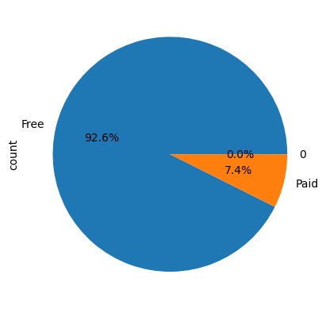

```python
df['Type'].value_counts().plot(kind = 'pie' , autopct = '%0.1f%%')
```

UNIVARIATE ANALYSIS ON THE PRICE COLUMNS

1.the main error in the price column is the '$' sign which will be removed further from the datset

2.Change the astype of the column from object to float for better undestanding

```python
df['Price'].value_counts()
```

```
Price
0         10040
$0.99       148
$2.99       129
$1.99        73
$4.99        72
          ...
$1.75         1
$14.00        1
$4.85         1
$46.99        1
$1.04         1
Name: count, Length: 93, dtype: int64
```

UNIVARIATE ANALYSIS ON THE CONTENT RATING

1.From the pie chart we can say that the 80.4% CONTENT IS FOR EVERYONE

2.From the pie chart we can say that the 11.1% CONTENT IS FOR TEEN

3.From the pie chart we can say that the 4.6% CONTENT IS FOR MATURE 17+

4.From the pie chart we can say that the 3.8% CONTENT IS FOR EVERYONE 10+

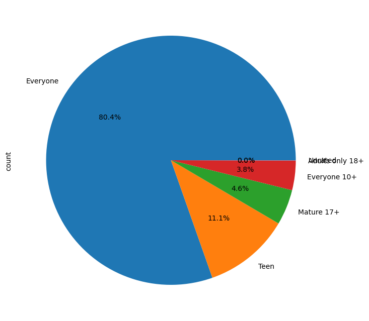

```python
plt.figure(figsize = (8,10))
df['Content Rating'].value_counts().plot(kind = 'pie' , autopct = '%0.1f%%')
```

```python
df['Genres'].value_counts()
```

```
Genres
Tools                     842
Entertainment             623
Education                 549
Medical                   463
Business                  460
                         ...
Arcade;Pretend Play         1
Card;Brain Games            1
Lifestyle;Pretend Play      1
Comics;Creativity           1
Strategy;Creativity         1
Name: count, Length: 120, dtype: int64
```

```python
df.columns
```

```
Index(['App', 'Category', 'Rating', 'Reviews', 'Size', 'Installs', 'Type',
       'Price', 'Content Rating', 'Genres', 'Last Updated', 'Current Ver',
       'Android Ver'],
      dtype='object')
```

Univariate Analyis on the current var and andorid ver

1.varies with device should be removed from the datset same for the current ver and andorid ver t

2.in android ver we have to change the rating format

```python
df['Current Ver'].value_counts()
```

```
Current Ver
Varies with device    1459
1.0                    809
1.1                    264
1.2                    178
2.0                    151
                      ...
1.0.17.3905              1
15.1.2                   1
4.94.19                  1
1.1.11.11                1
2.0.148.0                1
Name: count, Length: 2832, dtype: int64
```

```python
df['Android Ver'].value_counts()
```

```
Android Ver
4.1 and up            2451
4.0.3 and up          1501
4.0 and up            1375
Varies with device    1362
4.4 and up             980
2.3 and up             652
5.0 and up             601
4.2 and up             394
2.3.3 and up           281
2.2 and up             244
4.3 and up             243
3.0 and up             241
2.1 and up             134
1.6 and up             116
6.0 and up              60
7.0 and up              42
3.2 and up              36
2.0 and up              32
5.1 and up              24
1.5 and up              20
4.4W and up             12
3.1 and up              10
2.0.1 and up             7
8.0 and up               6
7.1 and up               3
4.0.3 - 7.1.1            2
5.0 - 8.0                2
1.0 and up               2
7.0 - 7.1.1              1
4.1 - 7.1.1              1
5.0 - 6.0                1
2.2 - 7.1.1              1
5.0 - 7.1.1              1
Name: count, dtype: int64
```

```python
df.info()
```

```
<class 'pandas.core.frame.DataFrame'>
RangeIndex: 10841 entries, 0 to 10840
Data columns (total 13 columns):
 #   Column          Non-Null Count  Dtype
---  ------          --------------  -----
 0   App             10841 non-null  object
 1   Category        10841 non-null  object
 2   Rating          9367 non-null   float64
 3   Reviews         10841 non-null  object
 4   Size            10841 non-null  object
 5   Installs        10841 non-null  object
 6   Type            10840 non-null  object
 7   Price           10841 non-null  object
 8   Content Rating  10840 non-null  object
 9   Genres          10841 non-null  object
 10  Last Updated    10841 non-null  object
 11  Current Ver     10833 non-null  object
 12  Android Ver     10838 non-null  object
dtypes: float64(1), object(12)
memory usage: 1.1+ MB
```

```python
df.head()
```

|  | App | Category | Rating | Reviews | Size | Installs | Type | Price | Content Rating | Genres | Last Updated | Current Ver | Android Ver |
| --- | --- | --- | --- | --- | --- | --- | --- | --- | --- | --- | --- | --- | --- |
| 0 | Photo Editor & Candy Camera & Grid & ScrapBook | ART_AND_DESIGN | 4.1 | 159 | 19M | 10,000+ | Free | 0 | Everyone | Art & Design | January 7, 2018 | 1.0.0 | 4.0.3 and up |
| 1 | Coloring book moana | ART_AND_DESIGN | 3.9 | 967 | 14M | 500,000+ | Free | 0 | Everyone | Art & Design;Pretend Play | January 15, 2018 | 2.0.0 | 4.0.3 and up |
| 2 | U Launcher Lite – FREE Live Cool Themes, Hide ... | ART_AND_DESIGN | 4.7 | 87510 | 8.7M | 5,000,000+ | Free | 0 | Everyone | Art & Design | August 1, 2018 | 1.2.4 | 4.0.3 and up |
| 3 | Sketch - Draw & Paint | ART_AND_DESIGN | 4.5 | 215644 | 25M | 50,000,000+ | Free | 0 | Teen | Art & Design | June 8, 2018 | Varies with device | 4.2 and up |
| 4 | Pixel Draw - Number Art Coloring Book | ART_AND_DESIGN | 4.3 | 967 | 2.8M | 100,000+ | Free | 0 | Everyone | Art & Design;Creativity | June 20, 2018 | 1.1 | 4.4 and up |

CLEANING DATA AND MANIPULATING DATA CONVERT SOME COLUMNS FROM OBJECT TO INTEGER FORMAT

```python
df['App'].value_counts()
```

```
App
ROBLOX                                                9
CBS Sports App - Scores, News, Stats & Watch Live     8
ESPN                                                  7
Duolingo: Learn Languages Free                        7
Candy Crush Saga                                      7
                                                     ..
Meet U - Get Friends for Snapchat, Kik & Instagram    1
U-Report                                              1
U of I Community Credit Union                         1
Waiting For U Launcher Theme                          1
iHoroscope - 2018 Daily Horoscope & Astrology         1
Name: count, Length: 9660, dtype: int64
```

```python
df[df['App'] == 'ROBLOX']
```

|  | App | Category | Rating | Reviews | Size | Installs | Type | Price | Content Rating | Genres | Last Updated | Current Ver | Android Ver |
| --- | --- | --- | --- | --- | --- | --- | --- | --- | --- | --- | --- | --- | --- |
| 1653 | ROBLOX | GAME | 4.5 | 4447388 | 67M | 100,000,000+ | Free | 0 | Everyone 10+ | Adventure;Action & Adventure | July 31, 2018 | 2.347.225742 | 4.1 and up |
| 1701 | ROBLOX | GAME | 4.5 | 4447346 | 67M | 100,000,000+ | Free | 0 | Everyone 10+ | Adventure;Action & Adventure | July 31, 2018 | 2.347.225742 | 4.1 and up |
| 1748 | ROBLOX | GAME | 4.5 | 4448791 | 67M | 100,000,000+ | Free | 0 | Everyone 10+ | Adventure;Action & Adventure | July 31, 2018 | 2.347.225742 | 4.1 and up |
| 1841 | ROBLOX | GAME | 4.5 | 4449882 | 67M | 100,000,000+ | Free | 0 | Everyone 10+ | Adventure;Action & Adventure | July 31, 2018 | 2.347.225742 | 4.1 and up |
| 1870 | ROBLOX | GAME | 4.5 | 4449910 | 67M | 100,000,000+ | Free | 0 | Everyone 10+ | Adventure;Action & Adventure | July 31, 2018 | 2.347.225742 | 4.1 and up |
| 2016 | ROBLOX | FAMILY | 4.5 | 4449910 | 67M | 100,000,000+ | Free | 0 | Everyone 10+ | Adventure;Action & Adventure | July 31, 2018 | 2.347.225742 | 4.1 and up |
| 2088 | ROBLOX | FAMILY | 4.5 | 4450855 | 67M | 100,000,000+ | Free | 0 | Everyone 10+ | Adventure;Action & Adventure | July 31, 2018 | 2.347.225742 | 4.1 and up |
| 2206 | ROBLOX | FAMILY | 4.5 | 4450890 | 67M | 100,000,000+ | Free | 0 | Everyone 10+ | Adventure;Action & Adventure | July 31, 2018 | 2.347.225742 | 4.1 and up |
| 4527 | ROBLOX | FAMILY | 4.5 | 4443407 | 67M | 100,000,000+ | Free | 0 | Everyone 10+ | Adventure;Action & Adventure | July 31, 2018 | 2.347.225742 | 4.1 and up |

```python
df.drop_duplicates(subset = 'App' ,inplace  = True)
```

```python
df
```

|  | App | Category | Rating | Reviews | Size | Installs | Type | Price | Content Rating | Genres | Last Updated | Current Ver | Android Ver |
| --- | --- | --- | --- | --- | --- | --- | --- | --- | --- | --- | --- | --- | --- |
| 0 | Photo Editor & Candy Camera & Grid & ScrapBook | ART_AND_DESIGN | 4.1 | 159 | 19M | 10,000+ | Free | 0 | Everyone | Art & Design | January 7, 2018 | 1.0.0 | 4.0.3 and up |
| 1 | Coloring book moana | ART_AND_DESIGN | 3.9 | 967 | 14M | 500,000+ | Free | 0 | Everyone | Art & Design;Pretend Play | January 15, 2018 | 2.0.0 | 4.0.3 and up |
| 2 | U Launcher Lite – FREE Live Cool Themes, Hide ... | ART_AND_DESIGN | 4.7 | 87510 | 8.7M | 5,000,000+ | Free | 0 | Everyone | Art & Design | August 1, 2018 | 1.2.4 | 4.0.3 and up |
| 3 | Sketch - Draw & Paint | ART_AND_DESIGN | 4.5 | 215644 | 25M | 50,000,000+ | Free | 0 | Teen | Art & Design | June 8, 2018 | Varies with device | 4.2 and up |
| 4 | Pixel Draw - Number Art Coloring Book | ART_AND_DESIGN | 4.3 | 967 | 2.8M | 100,000+ | Free | 0 | Everyone | Art & Design;Creativity | June 20, 2018 | 1.1 | 4.4 and up |
| ... | ... | ... | ... | ... | ... | ... | ... | ... | ... | ... | ... | ... | ... |
| 10836 | Sya9a Maroc - FR | FAMILY | 4.5 | 38 | 53M | 5,000+ | Free | 0 | Everyone | Education | July 25, 2017 | 1.48 | 4.1 and up |
| 10837 | Fr. Mike Schmitz Audio Teachings | FAMILY | 5.0 | 4 | 3.6M | 100+ | Free | 0 | Everyone | Education | July 6, 2018 | 1.0 | 4.1 and up |
| 10838 | Parkinson Exercices FR | MEDICAL | NaN | 3 | 9.5M | 1,000+ | Free | 0 | Everyone | Medical | January 20, 2017 | 1.0 | 2.2 and up |
| 10839 | The SCP Foundation DB fr nn5n | BOOKS_AND_REFERENCE | 4.5 | 114 | Varies with device | 1,000+ | Free | 0 | Mature 17+ | Books & Reference | January 19, 2015 | Varies with device | Varies with device |
| 10840 | iHoroscope - 2018 Daily Horoscope & Astrology | LIFESTYLE | 4.5 | 398307 | 19M | 10,000,000+ | Free | 0 | Everyone | Lifestyle | July 25, 2018 | Varies with device | Varies with device |

9660 rows × 13 columns

CLEANING DATA

1.astype should be changed of : Reviews , size , Installs , price

```python
df['Reviews'] = df['Reviews'].astype(int)
```

```python
df[df['Reviews'].str.contains('M')]
```

|  | App | Category | Rating | Reviews | Size | Installs | Type | Price | Content Rating | Genres | Last Updated | Current Ver | Android Ver |
| --- | --- | --- | --- | --- | --- | --- | --- | --- | --- | --- | --- | --- | --- |
| 10472 | Life Made WI-Fi Touchscreen Photo Frame | 1.9 | 19.0 | 3.0M | 1,000+ | Free | 0 | Everyone | NaN | February 11, 2018 | 1.0.19 | 4.0 and up | NaN |

```python
df = df[~df['Reviews'].str.contains('M')]
```

so we have successfully drop the this oulier row which was completely different from the rest of the columns values specially with the category , rating and Reviews

before dropping the row we was having 9660 rows so now after dropping we have 9659 rows

```python
df['Reviews'].info()
```

```
<class 'pandas.core.series.Series'>
Index: 9659 entries, 0 to 10840
Series name: Reviews
Non-Null Count  Dtype
--------------  -----
9659 non-null   int32
dtypes: int32(1)
memory usage: 113.2 KB
```

```python
df.head()
```

|  | App | Category | Rating | Reviews | Size | Installs | Type | Price | Content Rating | Genres | Last Updated | Current Ver | Android Ver |
| --- | --- | --- | --- | --- | --- | --- | --- | --- | --- | --- | --- | --- | --- |
| 0 | Photo Editor & Candy Camera & Grid & ScrapBook | ART_AND_DESIGN | 4.1 | 159 | 19M | 10,000+ | Free | 0 | Everyone | Art & Design | 2018-01-07 | 1.0.0 | 4.0.3 and up |
| 1 | Coloring book moana | ART_AND_DESIGN | 3.9 | 967 | 14M | 500,000+ | Free | 0 | Everyone | Art & Design;Pretend Play | 2018-01-15 | 2.0.0 | 4.0.3 and up |
| 2 | U Launcher Lite – FREE Live Cool Themes, Hide ... | ART_AND_DESIGN | 4.7 | 87510 | 8.7M | 5,000,000+ | Free | 0 | Everyone | Art & Design | 2018-08-01 | 1.2.4 | 4.0.3 and up |
| 3 | Sketch - Draw & Paint | ART_AND_DESIGN | 4.5 | 215644 | 25M | 50,000,000+ | Free | 0 | Teen | Art & Design | 2018-06-08 | Varies with device | 4.2 and up |
| 4 | Pixel Draw - Number Art Coloring Book | ART_AND_DESIGN | 4.3 | 967 | 2.8M | 100,000+ | Free | 0 | Everyone | Art & Design;Creativity | 2018-06-20 | 1.1 | 4.4 and up |

```python
df['Last Updated'].head()
```

```
0   2018-01-07
1   2018-01-15
2   2018-08-01
3   2018-06-08
4   2018-06-20
Name: Last Updated, dtype: datetime64[ns]
```

```python
df['Installs'].head()
```

```
0        10,000+
1       500,000+
2     5,000,000+
3    50,000,000+
4       100,000+
Name: Installs, dtype: object
```

```python
df.head()
```

|  | App | Category | Rating | Reviews | Size | Installs | Type | Price | Content Rating | Genres | Last Updated | Current Ver | Android Ver |
| --- | --- | --- | --- | --- | --- | --- | --- | --- | --- | --- | --- | --- | --- |
| 0 | Photo Editor & Candy Camera & Grid & ScrapBook | ART_AND_DESIGN | 4.1 | 159 | 19M | 10000 | Free | 0 | Everyone | Art & Design | 2018-01-07 | 1.0.0 | 4.0.3 and up |
| 1 | Coloring book moana | ART_AND_DESIGN | 3.9 | 967 | 14M | 500000 | Free | 0 | Everyone | Art & Design;Pretend Play | 2018-01-15 | 2.0.0 | 4.0.3 and up |
| 2 | U Launcher Lite – FREE Live Cool Themes, Hide ... | ART_AND_DESIGN | 4.7 | 87510 | 8.7M | 5000000 | Free | 0 | Everyone | Art & Design | 2018-08-01 | 1.2.4 | 4.0.3 and up |
| 3 | Sketch - Draw & Paint | ART_AND_DESIGN | 4.5 | 215644 | 25M | 50000000 | Free | 0 | Teen | Art & Design | 2018-06-08 | Varies with device | 4.2 and up |
| 4 | Pixel Draw - Number Art Coloring Book | ART_AND_DESIGN | 4.3 | 967 | 2.8M | 100000 | Free | 0 | Everyone | Art & Design;Creativity | 2018-06-20 | 1.1 | 4.4 and up |

now working with size columns

*now we can see that that size should be in integer but it is in string format

*and their is alsi issue where we can see the size difference between the MB and KB

*after replacing the varies with device input with the nan values and the convert then into them into the float so we can do analysis further

```python
df['Size'] = [x.strip().replace('k','') for x in df.Size]
df['Size'] = [x.strip().replace('M','') for x in df.Size]
```

```python
df.info()
```

[output not shown]

```python
def convert(val):
     if val == 'Varies with device':
        return np.nan
     return val

df['Size'] = df['Size'].apply(lambda x: convert(x))
```

```python
df['Size'] = df['Size'].astype(float)
```

```python
df['Size'].isnull().sum()
```

```
1227
```

```python
mean_size = df[~df['Size'].isnull()]['Size'].mean()
```

```python
max_size = df[~df['Size'].isnull()]['Size'].max()
```

```python
min_size = df[~df['Size'].isnull()]['Size'].min()
```

```python
median_size = df[~df['Size'].isnull()]['Size'].median()
```

```python
df.info()
```

[output not shown]

```python
df['Price'].value_counts()
```

```
Price
0          8903
$0.99       145
$2.99       124
$1.99        73
$4.99        70
           ...
$18.99        1
$389.99       1
$19.90        1
$1.75         1
$1.04         1
Name: count, Length: 92, dtype: int64
```

```python
df['Price'] = [x.strip().replace('$','') for x in df.Price]
```

```python
df2['Price'].value_counts()
```

```python
df['Price'] = df['Price'].astype(float)
```

```python
df['Price'].value_counts()
```

[output not shown]

```python
df['Price'].value_counts()
```

[output not shown]

```python
df.info()
```

[output not shown]

```python
cat_data = df.select_dtypes(exclude = np.number)
cat_col = cat_data.columns
cat_col
```

```
Index(['App', 'Category', 'Size', 'Type', 'Price', 'Content Rating', 'Genres',
       'Last Updated', 'Current Ver', 'Android Ver'],
      dtype='object')
```

```python
df['Current Ver'].reset_index()
```

|  | index | Current Ver |
| --- | --- | --- |
| 0 | 0 | 1.0.0 |
| 1 | 1 | 2.0.0 |
| 2 | 2 | 1.2.4 |
| 3 | 3 | Varies with device |
| 4 | 4 | 1.1 |
| ... | ... | ... |
| 9654 | 10836 | 1.48 |
| 9655 | 10837 | 1.0 |
| 9656 | 10838 | 1.0 |
| 9657 | 10839 | Varies with device |
| 9658 | 10840 | Varies with device |

9659 rows × 2 columns

```python
df['Size'].isnull().sum()
```

```
1227
```

```python
df[df['Type'].isnull()]
```

|  | App | Category | Rating | Reviews | Size | Installs | Type | Price | Content Rating | Genres | Last Updated | Current Ver | Android Ver |
| --- | --- | --- | --- | --- | --- | --- | --- | --- | --- | --- | --- | --- | --- |
| 9148 | Command & Conquer: Rivals | FAMILY | NaN | 0 | NaN | 0 | NaN | 0 | Everyone 10+ | Strategy | 2018-06-28 | Varies with device | Varies with device |

```python
df['Type'].mode()
```

```
0    Free
Name: Type, dtype: object
```

```python
df['Rating'].isnull().sum()
```

```
1463
```

```python
df['Rating'].mean()
```

```
4.173243045387994
```

```python
df.columns
```

```
Index(['App', 'Category', 'Rating', 'Reviews', 'Size', 'Installs', 'Type',
       'Price', 'Content Rating', 'Genres', 'Last Updated', 'Current Ver',
       'Android Ver'],
      dtype='object')
```

cleaning data of current ver and android ver

1.there are total 8 null values in Current Ver from the dataset

2.the mode of the current Ver is (varies with device)

.

1.now moving forward with android

```python
null_in_current_ver = df['Current Ver'].isnull().sum()
null_in_current_ver
```

```
8
```

```python
df['Current Ver'].mode()
```

```
0    Varies with device
Name: Current Ver, dtype: object
```

```python
df = df[df['Current Ver'].notna()]
df
```

|  | App | Category | Rating | Reviews | Size | Installs | Type | Price | Content Rating | Genres | Last Updated | Current Ver | Android Ver |
| --- | --- | --- | --- | --- | --- | --- | --- | --- | --- | --- | --- | --- | --- |
| 0 | Photo Editor & Candy Camera & Grid & ScrapBook | ART_AND_DESIGN | 4.1 | 159 | 19 | 10000 | Free | 0 | Everyone | Art & Design | 2018-01-07 | 1.0.0 | 4.0.3 and up |
| 1 | Coloring book moana | ART_AND_DESIGN | 3.9 | 967 | 14 | 500000 | Free | 0 | Everyone | Art & Design;Pretend Play | 2018-01-15 | 2.0.0 | 4.0.3 and up |
| 2 | U Launcher Lite – FREE Live Cool Themes, Hide ... | ART_AND_DESIGN | 4.7 | 87510 | 8.7 | 5000000 | Free | 0 | Everyone | Art & Design | 2018-08-01 | 1.2.4 | 4.0.3 and up |
| 3 | Sketch - Draw & Paint | ART_AND_DESIGN | 4.5 | 215644 | 25 | 50000000 | Free | 0 | Teen | Art & Design | 2018-06-08 | Varies with device | 4.2 and up |
| 4 | Pixel Draw - Number Art Coloring Book | ART_AND_DESIGN | 4.3 | 967 | 2.8 | 100000 | Free | 0 | Everyone | Art & Design;Creativity | 2018-06-20 | 1.1 | 4.4 and up |
| ... | ... | ... | ... | ... | ... | ... | ... | ... | ... | ... | ... | ... | ... |
| 10836 | Sya9a Maroc - FR | FAMILY | 4.5 | 38 | 53 | 5000 | Free | 0 | Everyone | Education | 2017-07-25 | 1.48 | 4.1 and up |
| 10837 | Fr. Mike Schmitz Audio Teachings | FAMILY | 5.0 | 4 | 3.6 | 100 | Free | 0 | Everyone | Education | 2018-07-06 | 1.0 | 4.1 and up |
| 10838 | Parkinson Exercices FR | MEDICAL | NaN | 3 | 9.5 | 1000 | Free | 0 | Everyone | Medical | 2017-01-20 | 1.0 | 2.2 and up |
| 10839 | The SCP Foundation DB fr nn5n | BOOKS_AND_REFERENCE | 4.5 | 114 | NaN | 1000 | Free | 0 | Mature 17+ | Books & Reference | 2015-01-19 | Varies with device | Varies with device |
| 10840 | iHoroscope - 2018 Daily Horoscope & Astrology | LIFESTYLE | 4.5 | 398307 | 19 | 10000000 | Free | 0 | Everyone | Lifestyle | 2018-07-25 | Varies with device | Varies with device |

9651 rows × 13 columns

HANDLING THE NULL VALUES IN THE DATASET

```python
df['Android Ver'].isnull().sum()
```

```
2
```

```python
df[df['Android Ver'].isnull()]
```

[output not shown]

```python
df['Android Ver'].nunique()
```

```
33
```

```python
df.shape
```

```
(9651, 13)
```

```python
df = df[df['Android Ver'].notna()]
```

```python
df
```

|  | App | Category | Rating | Reviews | Size | Installs | Type | Price | Content Rating | Genres | Last Updated | Current Ver | Android Ver |
| --- | --- | --- | --- | --- | --- | --- | --- | --- | --- | --- | --- | --- | --- |
| 0 | Photo Editor & Candy Camera & Grid & ScrapBook | ART_AND_DESIGN | 4.1 | 159 | 19 | 10000 | Free | 0 | Everyone | Art & Design | 2018-01-07 | 1.0.0 | 4.0.3 and up |
| 1 | Coloring book moana | ART_AND_DESIGN | 3.9 | 967 | 14 | 500000 | Free | 0 | Everyone | Art & Design;Pretend Play | 2018-01-15 | 2.0.0 | 4.0.3 and up |
| 2 | U Launcher Lite – FREE Live Cool Themes, Hide ... | ART_AND_DESIGN | 4.7 | 87510 | 8.7 | 5000000 | Free | 0 | Everyone | Art & Design | 2018-08-01 | 1.2.4 | 4.0.3 and up |
| 3 | Sketch - Draw & Paint | ART_AND_DESIGN | 4.5 | 215644 | 25 | 50000000 | Free | 0 | Teen | Art & Design | 2018-06-08 | Varies with device | 4.2 and up |
| 4 | Pixel Draw - Number Art Coloring Book | ART_AND_DESIGN | 4.3 | 967 | 2.8 | 100000 | Free | 0 | Everyone | Art & Design;Creativity | 2018-06-20 | 1.1 | 4.4 and up |
| ... | ... | ... | ... | ... | ... | ... | ... | ... | ... | ... | ... | ... | ... |
| 10836 | Sya9a Maroc - FR | FAMILY | 4.5 | 38 | 53 | 5000 | Free | 0 | Everyone | Education | 2017-07-25 | 1.48 | 4.1 and up |
| 10837 | Fr. Mike Schmitz Audio Teachings | FAMILY | 5.0 | 4 | 3.6 | 100 | Free | 0 | Everyone | Education | 2018-07-06 | 1.0 | 4.1 and up |
| 10838 | Parkinson Exercices FR | MEDICAL | NaN | 3 | 9.5 | 1000 | Free | 0 | Everyone | Medical | 2017-01-20 | 1.0 | 2.2 and up |
| 10839 | The SCP Foundation DB fr nn5n | BOOKS_AND_REFERENCE | 4.5 | 114 | NaN | 1000 | Free | 0 | Mature 17+ | Books & Reference | 2015-01-19 | Varies with device | Varies with device |
| 10840 | iHoroscope - 2018 Daily Horoscope & Astrology | LIFESTYLE | 4.5 | 398307 | 19 | 10000000 | Free | 0 | Everyone | Lifestyle | 2018-07-25 | Varies with device | Varies with device |

9649 rows × 13 columns

```python
df.shape
```

```
(9649, 13)
```

```python
df['Type'].isnull().sum()
```

```
1
```

```python
df[df['Type'].isnull()]
```

|  | App | Category | Rating | Reviews | Size | Installs | Type | Price | Content Rating | Genres | Last Updated | Current Ver | Android Ver |
| --- | --- | --- | --- | --- | --- | --- | --- | --- | --- | --- | --- | --- | --- |
| 9148 | Command & Conquer: Rivals | FAMILY | NaN | 0 | NaN | 0 | NaN | 0 | Everyone 10+ | Strategy | 2018-06-28 | Varies with device | Varies with device |

```python
df['Type'].mode()
```

```
0    Free
Name: Type, dtype: object
```

```python
df.loc[9148,'Type'] = 'Free'
```

```python
df['Type'].isnull().sum()
```

```
0
```

```python
df.isnull().sum()
```

```
App                  0
Category             0
Rating            1459
Reviews              0
Size              1227
Installs             0
Type                 0
Price                0
Content Rating       0
Genres               0
Last Updated         0
Current Ver          0
Android Ver          0
dtype: int64
```

Handling the null values of rating column in the dataset

hence there are 1459 null values in the dataset where we can't drop the entire rows with null values if we do that we are going to lost large amount of data from the dataset

so will replace with mean or median from the remaining values of column

```python
round(df[df['Rating'].notna()]['Rating'].mean(),2)
```

```
4.17
```

```python
round(df[df['Rating'].notna()]['Rating'].median(),2)
```

```
4.3
```

```python
df[df['Rating'].notna()]['Rating'].mode()
```

```
0    4.3
Name: Rating, dtype: float64
```

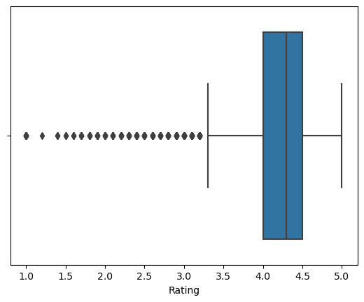

```python
sns.boxplot(x = 'Rating',data = df)
```

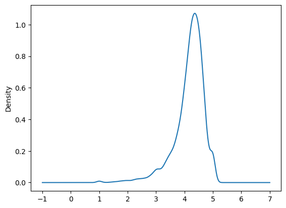

```python
df['Rating'].plot(kind = 'kde')
```

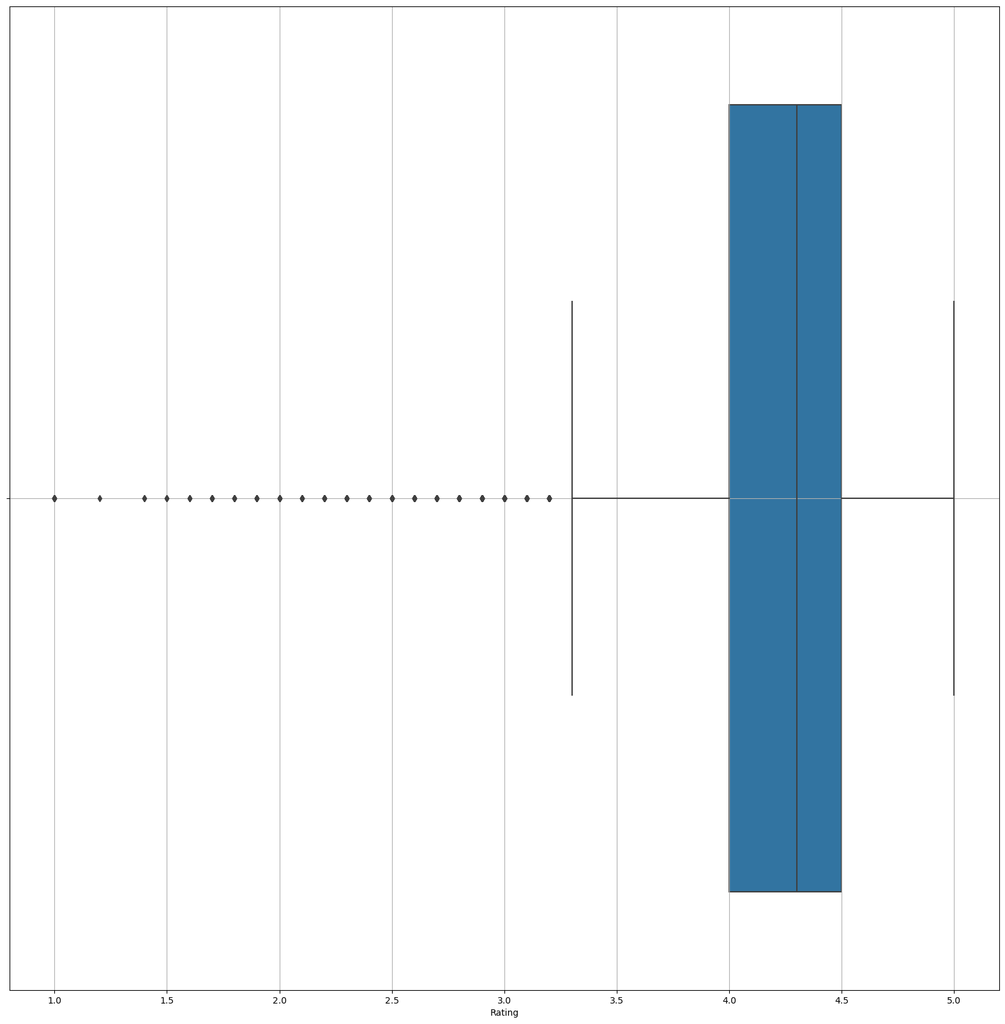

```python
plt.figure(figsize = (20,20))
sns.boxplot(x = 'Rating' , data = df,hue = 'Category')
plt.grid()
```

```python
df['Rating'].isnull().sum()
```

```
1459
```

```python
df['Rating'].skew()
```

```
-1.7443331394643597
```

```python
round(df['Rating'].mean(),2)
```

```
4.17
```

```python
df['Rating'].median()
```

```
4.3
```

```python
df
```

|  | App | Category | Rating | Reviews | Size | Installs | Type | Price | Content Rating | Genres | Last Updated | Current Ver | Android Ver |
| --- | --- | --- | --- | --- | --- | --- | --- | --- | --- | --- | --- | --- | --- |
| 0 | Photo Editor & Candy Camera & Grid & ScrapBook | ART_AND_DESIGN | 4.1 | 159 | 19 | 10000 | Free | 0 | Everyone | Art & Design | 2018-01-07 | 1.0.0 | 4.0.3 and up |
| 1 | Coloring book moana | ART_AND_DESIGN | 3.9 | 967 | 14 | 500000 | Free | 0 | Everyone | Art & Design;Pretend Play | 2018-01-15 | 2.0.0 | 4.0.3 and up |
| 2 | U Launcher Lite – FREE Live Cool Themes, Hide ... | ART_AND_DESIGN | 4.7 | 87510 | 8.7 | 5000000 | Free | 0 | Everyone | Art & Design | 2018-08-01 | 1.2.4 | 4.0.3 and up |
| 3 | Sketch - Draw & Paint | ART_AND_DESIGN | 4.5 | 215644 | 25 | 50000000 | Free | 0 | Teen | Art & Design | 2018-06-08 | Varies with device | 4.2 and up |
| 4 | Pixel Draw - Number Art Coloring Book | ART_AND_DESIGN | 4.3 | 967 | 2.8 | 100000 | Free | 0 | Everyone | Art & Design;Creativity | 2018-06-20 | 1.1 | 4.4 and up |
| ... | ... | ... | ... | ... | ... | ... | ... | ... | ... | ... | ... | ... | ... |
| 10836 | Sya9a Maroc - FR | FAMILY | 4.5 | 38 | 53 | 5000 | Free | 0 | Everyone | Education | 2017-07-25 | 1.48 | 4.1 and up |
| 10837 | Fr. Mike Schmitz Audio Teachings | FAMILY | 5.0 | 4 | 3.6 | 100 | Free | 0 | Everyone | Education | 2018-07-06 | 1.0 | 4.1 and up |
| 10838 | Parkinson Exercices FR | MEDICAL | NaN | 3 | 9.5 | 1000 | Free | 0 | Everyone | Medical | 2017-01-20 | 1.0 | 2.2 and up |
| 10839 | The SCP Foundation DB fr nn5n | BOOKS_AND_REFERENCE | 4.5 | 114 | NaN | 1000 | Free | 0 | Mature 17+ | Books & Reference | 2015-01-19 | Varies with device | Varies with device |
| 10840 | iHoroscope - 2018 Daily Horoscope & Astrology | LIFESTYLE | 4.5 | 398307 | 19 | 10000000 | Free | 0 | Everyone | Lifestyle | 2018-07-25 | Varies with device | Varies with device |

9649 rows × 13 columns

```python
df.isnull().sum()
```

```
App                  0
Category             0
Rating            1459
Reviews              0
Size              1227
Installs             0
Type                 0
Price                0
Content Rating       0
Genres               0
Last Updated         0
Current Ver          0
Android Ver          0
dtype: int64
```

```python
df['Rating'].skew()
```

```
-1.7443331394643597
```

```python
df.info()
```

```
<class 'pandas.core.frame.DataFrame'>
Index: 9649 entries, 0 to 10840
Data columns (total 13 columns):
 #   Column          Non-Null Count  Dtype
---  ------          --------------  -----
 0   App             9649 non-null   object
 1   Category        9649 non-null   object
 2   Rating          8190 non-null   float64
 3   Reviews         9649 non-null   int32
 4   Size            8422 non-null   object
 5   Installs        9649 non-null   int32
 6   Type            9649 non-null   object
 7   Price           9649 non-null   object
 8   Content Rating  9649 non-null   object
 9   Genres          9649 non-null   object
 10  Last Updated    9649 non-null   datetime64[ns]
 11  Current Ver     9649 non-null   object
 12  Android Ver     9649 non-null   object
dtypes: datetime64[ns](1), float64(1), int32(2), object(9)
memory usage: 1.2+ MB
```

```python
numeric_data = df.select_dtypes(include = np.number)
numeric_col = numeric_data.columns
numeric_data.head(10)
```

|  | Rating | Reviews | Installs |
| --- | --- | --- | --- |
| 0 | 4.1 | 159 | 10000 |
| 1 | 3.9 | 967 | 500000 |
| 2 | 4.7 | 87510 | 5000000 |
| 3 | 4.5 | 215644 | 50000000 |
| 4 | 4.3 | 967 | 100000 |
| 5 | 4.4 | 167 | 50000 |
| 6 | 3.8 | 178 | 50000 |
| 7 | 4.1 | 36815 | 1000000 |
| 8 | 4.4 | 13791 | 1000000 |
| 9 | 4.7 | 121 | 10000 |

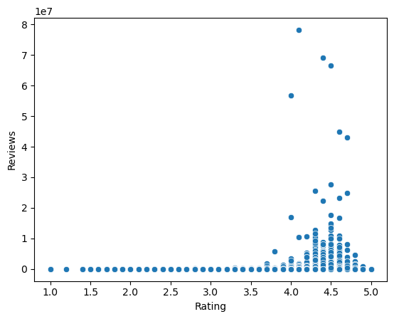

```python
sns.scatterplot(data = df , x = 'Rating' , y = 'Reviews')
```

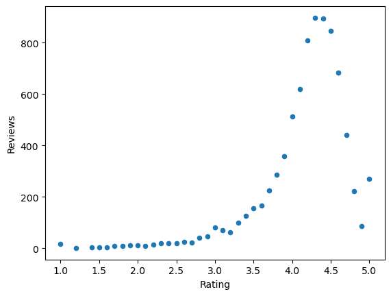

```python
df.groupby('Rating')['Reviews'].count().reset_index().plot(kind = 'scatter' , x = 'Rating',y = 'Reviews')
```

```python
plt.figure(figsize = (100,100))
plt.scatter(df['Rating'],df['Reviews'])
for i in range(df.shape[0]):
    plt.text(df['Rating'].values[i],df['Reviews'].values[i],df['Category'].values[i])
```

[output not shown]

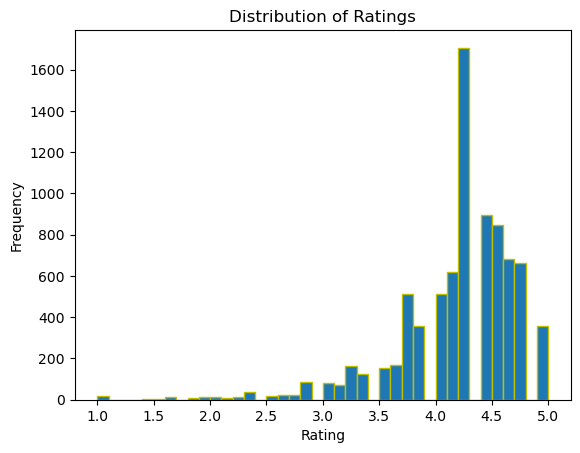

```python
df['Rating'].plot(kind = 'hist',xlabel = 'Rating' ,bins = 40,edgecolor  = 'y' , title = 'Distribution of Ratings')
```

[figure not shown]

```python
sns.pairplot(df)
```

[figure not shown]

```python
plt.figure(figsize = (10,4))
plt.scatter(df['Rating'],df['Installs'] , color = 'black', alpha = 0.6)
plt.xlabel('Rating')
plt.ylabel('Review')
```

[figure not shown]

```python
plt.figure(figsize = (10,4))
plt.scatter(df['Rating'],df['Price'],marker = 'o')
plt.xlabel('Rating')
plt.ylabel('Price')

plt.axhline(250,color = 'red')
plt.axvline(3.25 , color = 'y')
plt.axvline(4.5 , color = 'k')
```

```python
plt.figure(figsize = (10,6))
plt.scatter(df['Reviews'],df['Price'],color = 'cyan' , edgecolor = 'black')
plt.xlabel('Reviews')
plt.ylabel('Price')
```

[output not shown]

```python
df
```

[output not shown]

10841 rows × 13 columns

```python
plt.figure(figsize = (10,6))
plt.scatter(df['Reviews'],df['Price'],color = 'cyan' , edgecolor = 'black')
plt.xlabel('Reviews')
plt.ylabel('Price')
```

[output not shown]

```python
plt.figure(figsize = (10,6))
plt.scatter(df['Price'],df['Installs'] , color = 'red',edgecolor = 'Black')
plt.xlabel('Price')
plt.ylabel('Installs')
```

[output not shown]

```python
plt.figure(figsize = (12 , 12))

plt.subplot(2,2,1)
sns.boxplot(x = df['Rating'],palette = "Set2");
plt.title('Box plot of rating')

plt.subplot(2,2,2)
sns.boxplot(x = df['Reviews'] , palette = 'Set2');
plt.title('Box plot of Reviews')

plt.subplot(2,2,3)
sns.boxplot(x = df['Size'] , palette = 'Set2');
plt.title('Box plot of Size')

plt.subplot(2,2,4)
sns.boxplot(x = df['Installs'] , palette = 'Set2');
plt.title('Box plot of Installs')

plt.show()
```

[output not shown]

```python
df
```

[output not shown]

10841 rows × 13 columns

```python
df['Rating'].mean()
```

```
4.193338315362443
```

```python
df['Android Ver'].replace(to_replace=['4.4W and up','Varies with device'], value=['4.4','1.0'],inplace=True)
df['Android Ver'].replace({k: '1.0' for k in ['1.0','1.0 and up','1.5 and up','1.6 and up']},inplace=True)
df['Android Ver'].replace({k: '2.0' for k in ['2.0 and up','2.0.1 and up','2.1 and up','2.2 and up','2.2 - 7.1.1','2.3 and up','2.3.3 and up']},inplace=True)
df['Android Ver'].replace({k: '3.0' for k in ['3.0 and up','3.1 and up','3.2 and up']},inplace=True)
df['Android Ver'].replace({k: '4.0' for k in ['4.0 and up','4.0.3 and up','4.0.3 - 7.1.1','4.1 and up','4.1 - 7.1.1','4.2 and up','4.3 and up','4.4','4.4 and up']},inplace=True)
df['Android Ver'].replace({k: '5.0' for k in ['5.0 - 6.0','5.0 - 7.1.1','5.0 - 8.0','5.0 and up','5.1 and up']},inplace=True)
df['Android Ver'].replace({k: '6.0' for k in ['6.0 and up']},inplace=True)
df['Android Ver'].replace({k: '7.0' for k in ['7.0 - 7.1.1','7.0 and up','7.1 and up']},inplace=True)
df['Android Ver'].replace({k: '8.0' for k in ['8.0 and up']},inplace=True)
df['Android Ver'].fillna('1.0', inplace=True)
```

```python
df['Android Ver'] = df['Android Ver'].astype(float)
```

```python
df.info()
```

```
<class 'pandas.core.frame.DataFrame'>
RangeIndex: 10841 entries, 0 to 10840
Data columns (total 13 columns):
 #   Column          Non-Null Count  Dtype
---  ------          --------------  -----
 0   App             10841 non-null  object
 1   Category        10841 non-null  object
 2   Rating          9367 non-null   float64
 3   Reviews         10841 non-null  object
 4   Size            10841 non-null  object
 5   Installs        10841 non-null  object
 6   Type            10840 non-null  object
 7   Price           10841 non-null  object
 8   Content Rating  10840 non-null  object
 9   Genres          10841 non-null  object
 10  Last Updated    10841 non-null  object
 11  Current Ver     10833 non-null  object
 12  Android Ver     10841 non-null  float64
dtypes: float64(2), object(11)
memory usage: 1.1+ MB
```

```python
df
```

|  | App | Category | Rating | Reviews | Size | Installs | Type | Price | Content Rating | Genres | Last Updated | Current Ver | Android Ver |
| --- | --- | --- | --- | --- | --- | --- | --- | --- | --- | --- | --- | --- | --- |
| 0 | Photo Editor & Candy Camera & Grid & ScrapBook | ART_AND_DESIGN | 4.1 | 159 | 19M | 10,000+ | Free | 0 | Everyone | Art & Design | January 7, 2018 | 1.0.0 | 4.0 |
| 1 | Coloring book moana | ART_AND_DESIGN | 3.9 | 967 | 14M | 500,000+ | Free | 0 | Everyone | Art & Design;Pretend Play | January 15, 2018 | 2.0.0 | 4.0 |
| 2 | U Launcher Lite – FREE Live Cool Themes, Hide ... | ART_AND_DESIGN | 4.7 | 87510 | 8.7M | 5,000,000+ | Free | 0 | Everyone | Art & Design | August 1, 2018 | 1.2.4 | 4.0 |
| 3 | Sketch - Draw & Paint | ART_AND_DESIGN | 4.5 | 215644 | 25M | 50,000,000+ | Free | 0 | Teen | Art & Design | June 8, 2018 | Varies with device | 4.0 |
| 4 | Pixel Draw - Number Art Coloring Book | ART_AND_DESIGN | 4.3 | 967 | 2.8M | 100,000+ | Free | 0 | Everyone | Art & Design;Creativity | June 20, 2018 | 1.1 | 4.0 |
| ... | ... | ... | ... | ... | ... | ... | ... | ... | ... | ... | ... | ... | ... |
| 10836 | Sya9a Maroc - FR | FAMILY | 4.5 | 38 | 53M | 5,000+ | Free | 0 | Everyone | Education | July 25, 2017 | 1.48 | 4.0 |
| 10837 | Fr. Mike Schmitz Audio Teachings | FAMILY | 5.0 | 4 | 3.6M | 100+ | Free | 0 | Everyone | Education | July 6, 2018 | 1.0 | 4.0 |
| 10838 | Parkinson Exercices FR | MEDICAL | NaN | 3 | 9.5M | 1,000+ | Free | 0 | Everyone | Medical | January 20, 2017 | 1.0 | 2.0 |
| 10839 | The SCP Foundation DB fr nn5n | BOOKS_AND_REFERENCE | 4.5 | 114 | Varies with device | 1,000+ | Free | 0 | Mature 17+ | Books & Reference | January 19, 2015 | Varies with device | 1.0 |
| 10840 | iHoroscope - 2018 Daily Horoscope & Astrology | LIFESTYLE | 4.5 | 398307 | 19M | 10,000,000+ | Free | 0 | Everyone | Lifestyle | July 25, 2018 | Varies with device | 1.0 |

10841 rows × 13 columns

```python
df['Current Ver'].value_counts()
```

```
Current Ver
Varies with device    1459
1.0                    809
1.1                    264
1.2                    178
2.0                    151
                      ...
1.0.17.3905              1
15.1.2                   1
4.94.19                  1
1.1.11.11                1
2.0.148.0                1
Name: count, Length: 2832, dtype: int64
```

```python
df[df['Current Ver'] < '1.0']
```

|  | App | Category | Rating | Reviews | Size | Installs | Type | Price | Content Rating | Genres | Last Updated | Current Ver | Android Ver |
| --- | --- | --- | --- | --- | --- | --- | --- | --- | --- | --- | --- | --- | --- |
| 39 | How To Color Disney Princess - Coloring Pages | ART_AND_DESIGN | 4.0 | 591 | 9.4M | 500,000+ | Free | 0 | Everyone | Art & Design | March 31, 2018 | 1 | 4.0 |
| 65 | Check Vehicle Tax | AUTO_AND_VEHICLES | 3.9 | 295 | 2.7M | 10,000+ | Free | 0 | Everyone | Auto & Vehicles | July 30, 2018 | 0.2.1 | 4.0 |
| 224 | ATI Cargoes and Transportation | BUSINESS | 4.7 | 4162 | 7.5M | 100,000+ | Free | 0 | Everyone | Business | July 24, 2018 | 0.9.4 | 4.0 |
| 384 | Hangouts Dialer - Call Phones | COMMUNICATION | 4.0 | 122498 | 79k | 10,000,000+ | Free | 0 | Everyone | Communication | September 2, 2015 | 0.1.100944346 | 4.0 |
| 585 | Sweet mi - unlimited hunnam hunting blind date | DATING | 4.0 | 6191 | 27M | 500,000+ | Free | 0 | Mature 17+ | Dating | July 12, 2018 | 0.0.73 | 4.0 |
| ... | ... | ... | ... | ... | ... | ... | ... | ... | ... | ... | ... | ... | ... |
| 10741 | Fingerprint Quick Action | TOOLS | 4.2 | 8484 | 1.7M | 1,000,000+ | Free | 0 | Everyone | Tools | July 22, 2018 | 0.15.2 | 6.0 |
| 10742 | GKPB FP Online Church | LIFESTYLE | 5.0 | 32 | 7.9M | 1,000+ | Free | 0 | Everyone | Lifestyle | December 31, 2017 | 0.7.1 | 4.0 |
| 10819 | Fanfic-FR | BOOKS_AND_REFERENCE | 3.3 | 52 | 3.6M | 5,000+ | Free | 0 | Teen | Books & Reference | August 5, 2017 | 0.3.4 | 4.0 |
| 10822 | PLMGSS FR | PRODUCTIVITY | NaN | 0 | 3.1M | 10+ | Free | 0 | Everyone | Productivity | December 1, 2017 | 1 | 4.0 |
| 10833 | Chemin (fr) | BOOKS_AND_REFERENCE | 4.8 | 44 | 619k | 1,000+ | Free | 0 | Everyone | Books & Reference | March 23, 2014 | 0.8 | 2.0 |

205 rows × 13 columns

```python
df['Last Updated'] = pd.to_datetime(df['Last Updated'])
```

```python
df['Last Updated']
```

[output not shown]